# R Base Plotting

**Instructions: All plots generated for this homework assignment must be a part of the R Base plotting functions. This means no GGPLOTS, plot.ly or any other package plot functions, only R Base**

Name: Azar Najafli

**Step 1: Import the Global Orders 2016 data set using the read.csv function (5 points)**

```r
setwd("/Users/azarnajafli/Desktop/R")
getwd()
```

```
## [1] "/Users/azarnajafli/Desktop/R"
```

```r
data<-read.csv(file = "/Users/azarnajafli/Desktop/R/superstore.csv", header = T)
```

**Step 2 - Create a horizontal barplot of Total Sales by Market, ordered descending on total sales (i.e. the market with highest** **total sales should be on the top) (25 points)**

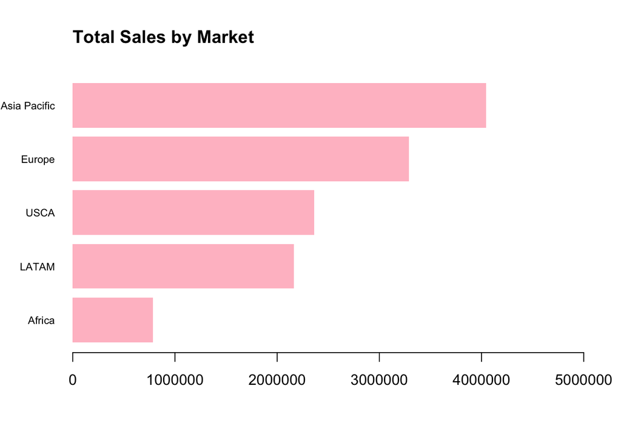

```r
data1 <- aggregate.data.frame(data$Sales,by=list(data$Market),sum)
names(data1)<- c("Market","Total_Sales")
A<- data1[order(data1$Total_Sales,decreasing=FALSE),]
barplot(A$Total_Sales,names.arg=A$Market,
       col = c("pink","pink","pink","pink","pink"),
       horiz = TRUE, border=NA,
       xlim=c(0,5000000),
       las =1, cex.names = 0.71)
        options(scipen = 999)
title("Total Sales by Market",adj = 0)
```

*Answer the following question: Does any market appear to be very different from the others for total sales?*

*Answer below:* Yes, Africa

*Can you visually indicate this market as a separate color from the others?*

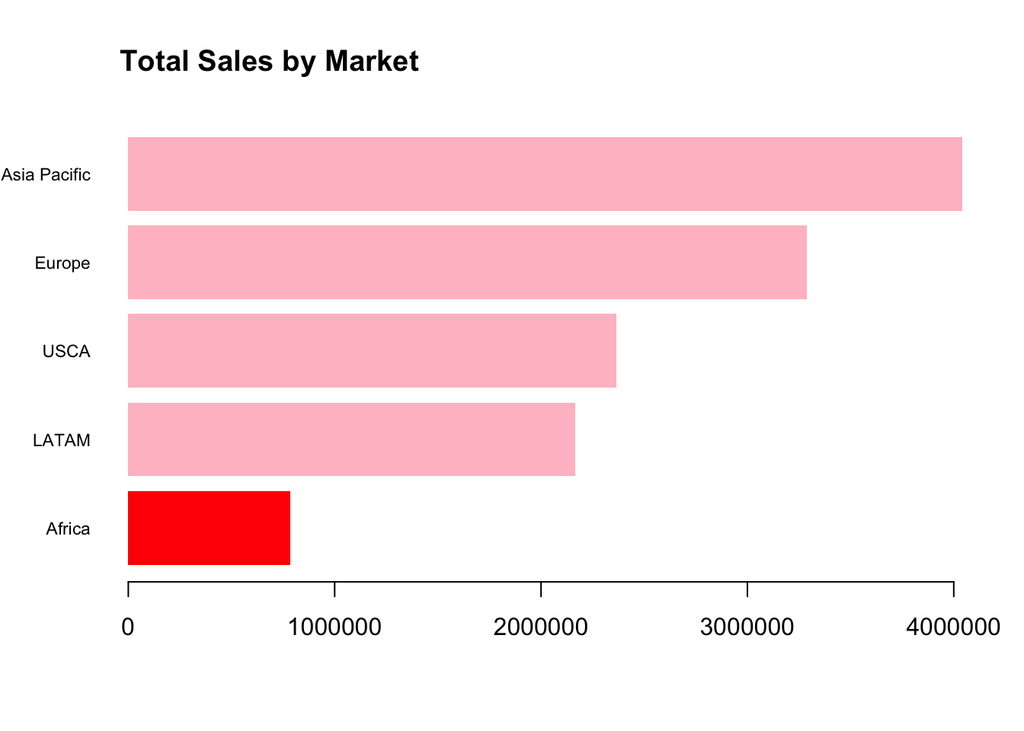

```r
barplot(A$Total_Sales,names.arg=A$Market,
       col = c("red","pink","pink","pink","pink"),
       horiz = TRUE, border=NA,
       las =1, cex.names = 0.71
       )
title("Total Sales by Market",adj = 0)
```

**Step 3 - Create a line chart total sales by year for each market (25 points)**

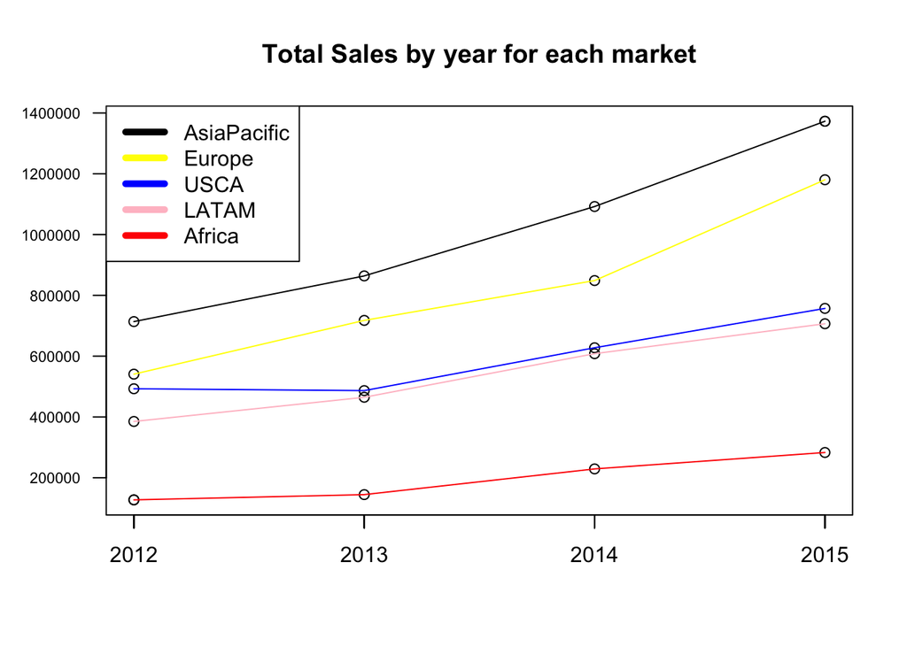

```r
data2<-aggregate.data.frame(data$Sales,by=list(data$Market,data$Order.Year),sum)
names(data2) = c("Market","Year","Total_Sales")

data2.AsiaPacific<- data2[data2$Market == "Asia Pacific",]
data2.Europe<- data2[data2$Market == "Europe",]
data2.USCA<- data2[data2$Market == "USCA",]
data2.LATAM<- data2[data2$Market == "LATAM",]
data2.Africa<- data2[data2$Market == "Africa",]

xrange <- range(data2$Year)
yrange <- range(data2$Total_Sales)

plot(xrange,
     yrange,
     xlab="",ylab="",
     xaxt="n",
     las= 1,
     cex.axis= 0.70,
     main = "Total Sales by year for each market")

axis(1, labels = as.character(data2$Year), at = as.numeric(data2$Year))

points(data2.AsiaPacific$Year, data2.AsiaPacific$Total_Sales)
points(data2.Europe$Year, data2.Europe$Total_Sales)
points(data2.USCA$Year, data2.USCA$Total_Sales)
points(data2.LATAM$Year, data2.LATAM$Total_Sales)
points(data2.Africa$Year, data2.Africa$Total_Sales)


lines(data2.AsiaPacific$Year, data2.AsiaPacific$Total_Sales,col = "black")
lines(data2.Europe$Year, data2.Europe$Total_Sales,col = "yellow")
lines(data2.USCA$Year, data2.USCA$Total_Sales,col = "blue")
lines(data2.LATAM$Year, data2.LATAM$Total_Sales,col = "pink")
lines(data2.Africa$Year, data2.Africa$Total_Sales,col = "red")
legend("topleft", legend=c("AsiaPacific","Europe","USCA","LATAM","Africa"), lwd=c(5,5), col=c("black","yellow","blue","pink","red"))
```

*Answer the following question: Does the same market appear to be different in your line graph as well?*

*Answer below:* Yes *Can you visually indicate this market as a separate color from the other markets in your graph?*

*Can you tell your markets apart from one another in your graph? If not consider what you need to add to your graph so that you can tell them apart* Yes, by labeling lines.

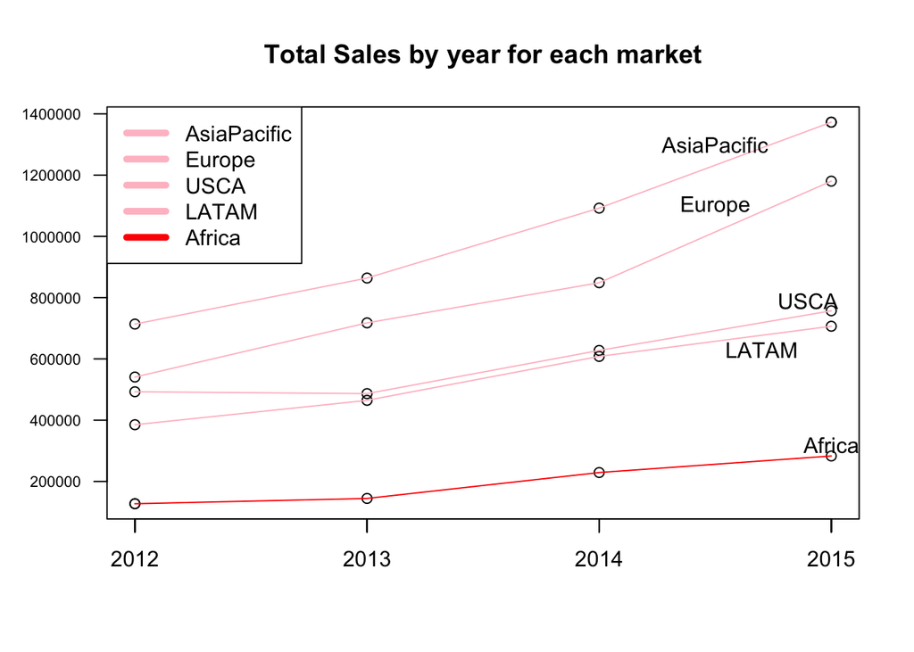

```r
plot(xrange,
     yrange,
     xlab="",ylab="",
     xaxt="n",
     las= 1,
     cex.axis= 0.70,
     main = "Total Sales by year for each market")

axis(1, labels = as.character(data2$Year), at = as.numeric(data2$Year))

points(data2.AsiaPacific$Year, data2.AsiaPacific$Total_Sales)
points(data2.Europe$Year, data2.Europe$Total_Sales)
points(data2.USCA$Year, data2.USCA$Total_Sales)
points(data2.LATAM$Year, data2.LATAM$Total_Sales)
points(data2.Africa$Year, data2.Africa$Total_Sales)


lines(data2.AsiaPacific$Year, data2.AsiaPacific$Total_Sales,col = "pink")
lines(data2.Europe$Year, data2.Europe$Total_Sales,col = "pink")
lines(data2.USCA$Year, data2.USCA$Total_Sales,col = "pink")
lines(data2.LATAM$Year, data2.LATAM$Total_Sales,col = "pink")
lines(data2.Africa$Year, data2.Africa$Total_Sales,col = "red")
legend("topleft", legend=c("AsiaPacific","Europe","USCA","LATAM","Africa"), lwd=c(5,5), col=c("pink","pink","pink","pink","red"))
text(2015, 320000, "Africa")
text(2014.7, 630000, "LATAM")
text(2014.9, 790000, "USCA")
text(2014.5, 1100000, "Europe")
text(2014.5, 1300000, "AsiaPacific")
```

**Step 4 - Create a box plot of total sales by market (25 points)**

*Hint: use the ylim parameter to restrict your graph so that you tell the boxes apart*

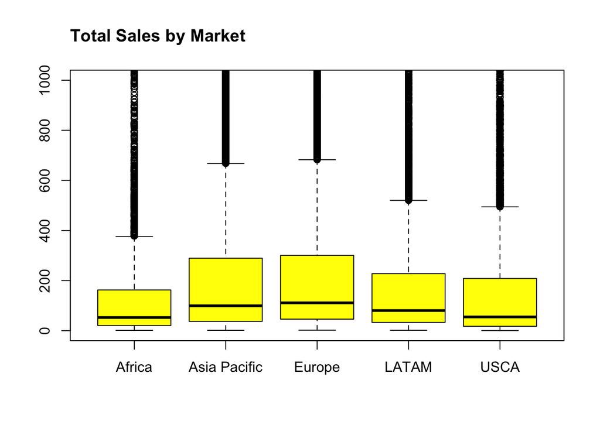

```r
boxplot(Sales~Market,
        data=data,
        ylim = range(0:1000),
        col= c("yellow","yellow","yellow","yellow","yellow" ) )
title("Total Sales by Market",adj=0)
```

*Does the general pattern you observe match that of the earlier steps 2 and 3?*

*Answer below:* Yes, we can see Africa contains the values mostly below other markets.

*What other insights can you draw from your box plot above?*

*Answer below:*

*Can you visually indicate this market as a separate color from the others in your boxplot graph?*

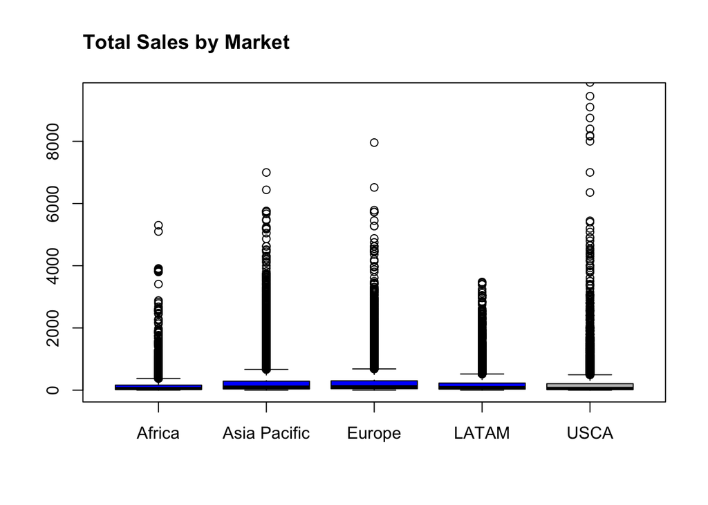

```r
boxplot(Sales~Market,
        data=data,
        ylim = range(0:9500),
        col= c("blue","blue","blue","blue","grey" ) )
title("Total Sales by Market",adj=0)
```

**Step 5 - Generate a different kind of graph other than what was produced in steps 2, 3, & 4 (20 points)**

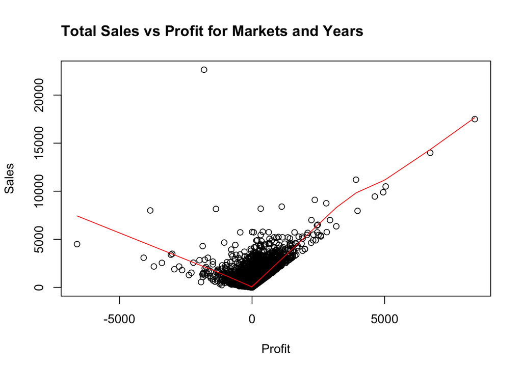

```r
data3 <- data[c('Profit', 'Sales')]
plot(x = data3$Profit, y = data3$Sales,
   xlab = "Profit",
   ylab = "Sales")
title("Total Sales vs Profit for Markets and Years",adj=0)
 lines(lowess(data3$Profit,data3$Sales), col="red")
```

*This means not a bar plot, line graph, or box plot. You need to use R Base plots for this question, not GGPLOT or any other plotting functions, only R Base.* We can observe an interesting trend from the scatter plot. In general market does not make a profit as main bubbles gathered around 0 profit. However, while the sales are in high volume, we have more positive profit.